# Covid91 vaccine study Final2023

javalos16

2023-08-02

# 1 Introduction

A new preventative vaccine (covid921) is under test in clinical trials. Given the nature of this vaccine it is suspected that the drug may exhibit different effectiveness across the variety of subpopulations tracked. Consider population subgroups by gender( guys and gals), drug use, and sexual orientation. Write a complete report that separately considers this drug for each subgroup and your recommendations as to whether people in the subgroup should take the vaccine. Structure your report in four sections each devoted to one of the four subgroups, use null and alternative hypothesis statements and correct statistical verbage when referencing p-values in conclusions.

## 1.1 Males

$H_0$; The vaccine is not effective in preventing Covid in males

$H_A$; The vaccine is effective in preventing Covid in males

Data for this study came from a FinalData file, provided by the professor.

##Methods

The response method used is cat~cat. Data used was based on data from FinalData. We have to subset the data to include male.

Graphical display: bar chart, numerical display and inferential results

numerical display

##Results

```r
maleData = filter (FinalData,sex == "M")
```

##Descriptive Results

##Graphical Descriptive Results

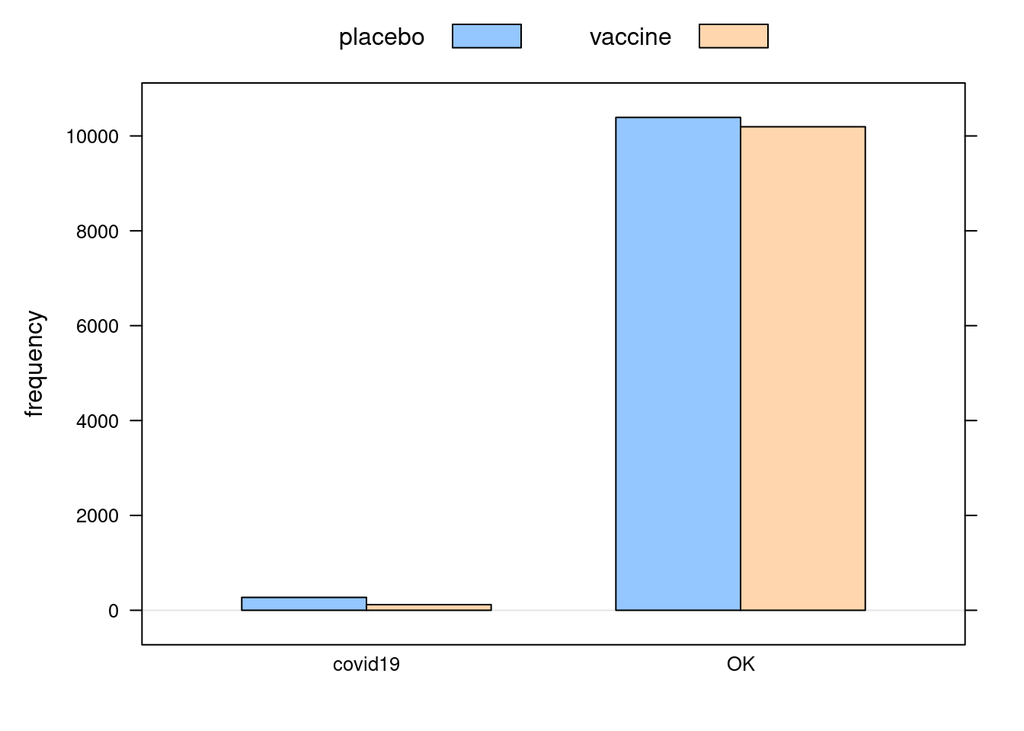

```r
barchartGC(~infected+treatment,data=maleData)
```

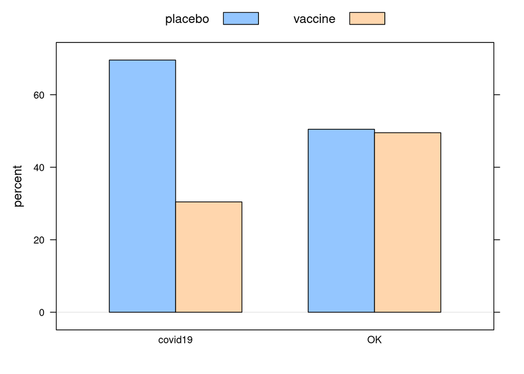

```r
barchartGC(~infected+treatment,data=maleData, type="percent")
```

The graph shows among those who got covid , the males who did got vaccine there was a difference between 30% with covid and 70% with placebo. Meanwhile Among the people who were OK that toke the vaccine, there was no significant difference.

##Numerical Descriptive Results

```r
table1 <- xtabs(~infected + treatment, data=maleData)
rowPerc(table1)
```

```
##          treatment
## infected  placebo vaccine  Total
##   covid19   69.57   30.43 100.00
##   OK        50.48   49.52 100.00
```

```r
colPerc(table1)
```

```
##          treatment
## infected  placebo vaccine
##   covid19    2.55    1.15
##   OK        97.45   98.85
##   Total    100.00  100.00
```

Among the people that took the placebo with 70% got covid and 30% did get covid, even with treatment. Among the people that were Ok and took the vaccine there was no significant difference.

##Inferential Results

```r
chisq.test(table1)
```

```
##
##  Pearson's Chi-squared test with Yates' continuity correction
##
## data:  table1
## X-squared = 55.183, df = 1, p-value = 1.098e-13
```

```r
chisqtestGC(table1)
```

```
## Pearson's Chi-squared test with Yates' continuity correction
##
## Observed Counts:
##          treatment
## infected  placebo vaccine
##   covid19     272     119
##   OK        10390   10194
##
## Counts Expected by Null:
##          treatment
## infected   placebo  vaccine
##   covid19   198.75   192.25
##   OK      10463.25 10120.75
##
## Contributions to the chi-square statistic:
##          treatment
## infected  placebo vaccine
##   covid19   26.99   27.91
##   OK         0.51    0.53
##
##
## Chi-Square Statistic = 55.1832
## Degrees of Freedom of the table = 1
## P-Value = 0
```

```r
fisher.test(table1)
```

```
##
##  Fisher's Exact Test for Count Data
##
## data:  table1
## p-value = 4.631e-14
## alternative hypothesis: true odds ratio is not equal to 1
## 95 percent confidence interval:
##  1.798068 2.810778
## sample estimates:
## odds ratio
##   2.242522
```

Based on the Fisher’s Exact you are P-value:0.00000000000004631 less likely to get covid.

## 1.2 Females

$H_0$; The vaccine is not effective in preventing Covid in Females

$H_A$; The vaccine is effective in preventing Covid in Females

Data for this study came from a FinalData file, provided by the professor.

##Methods

The response method used is cat~cat. Data used was based on data from FinalData. We have to subset the data to include female.

Graphical display: bar chart, numerical display and inferential results

numerical display

##Results

```r
femaleData = filter(FinalData, sex == "F")
```

##Descriptive Results

##Graphical Descriptive Results

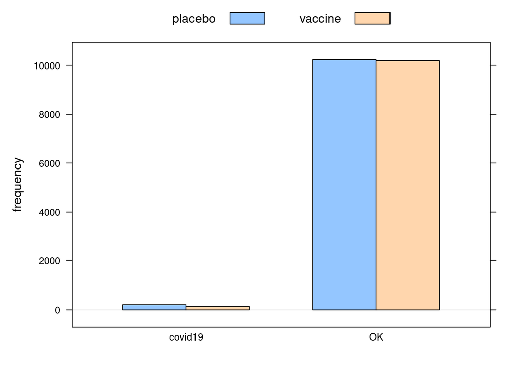

```r
barchartGC(~infected+treatment,data=femaleData)
```

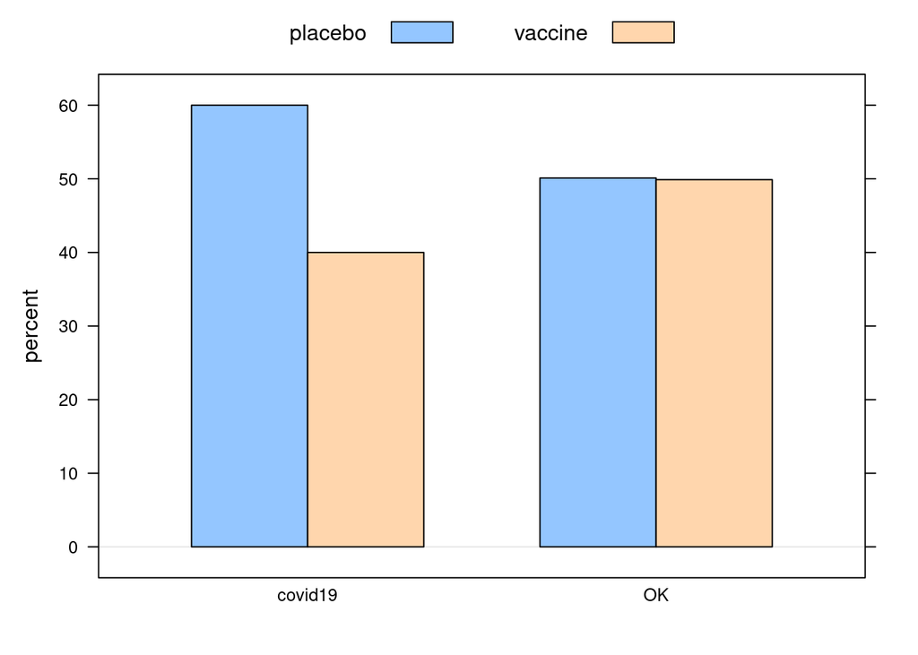

```r
barchartGC(~infected+treatment,data=femaleData, type="percent")
```

The graph shows among those who had covid , the females who did get vaccineted there was a difference of about 40% with covid and 60% placebo. Meanwhile Among the females who were OK that toke the vaccine, there was no significant difference.

##Numerical Descriptive Results

```r
table2 <- xtabs(~infected + treatment, data=femaleData)
rowPerc(table2)
```

```
##          treatment
## infected  placebo vaccine  Total
##   covid19   60.00   40.00 100.00
##   OK        50.12   49.88 100.00
```

```r
colPerc(table2)
```

```
##          treatment
## infected  placebo vaccine
##   covid19    2.04    1.37
##   OK        97.96   98.63
##   Total    100.00  100.00
```

Among the females who toke the vaccine that took the Covid vaccine there was a 20% difference in those who are vaccinated. The people that took the placebo with 20% more chance of being infected. Among the people that were Ok and took the vaccine there was no significant difference.

##Inferential Results

```r
chisq.test(table2)
```

```
##
##  Pearson's Chi-squared test with Yates' continuity correction
##
## data:  table2
## X-squared = 13.246, df = 1, p-value = 0.0002732
```

```r
chisqtestGC(table2)
```

```
## Pearson's Chi-squared test with Yates' continuity correction
##
## Observed Counts:
##          treatment
## infected  placebo vaccine
##   covid19     213     142
##   OK        10236   10189
##
## Counts Expected by Null:
##          treatment
## infected   placebo  vaccine
##   covid19   178.51   176.49
##   OK      10270.49 10154.51
##
## Contributions to the chi-square statistic:
##          treatment
## infected  placebo vaccine
##   covid19    6.66    6.74
##   OK         0.12    0.12
##
##
## Chi-Square Statistic = 13.246
## Degrees of Freedom of the table = 1
## P-Value = 3e-04
```

```r
fisher.test(table2)
```

```
##
##  Fisher's Exact Test for Count Data
##
## data:  table2
## p-value = 0.0002162
## alternative hypothesis: true odds ratio is not equal to 1
## 95 percent confidence interval:
##  1.199509 1.862988
## sample estimates:
## odds ratio
##   1.493076
```

Based on the Fisher’s Exact you are P-value:0.0002162 less likely to get covid.

## 1.3 LGBTQ

$H_0$; The vaccine is not effective in preventing Covid in LGBTQ

$H_A$; The vaccine is effective in preventing Covid in LGBTQ

Data for this study came from a FinalData file, provided by the professor.

##Methods

The response method used is cat~cat. Data used was based on data from FinalData. We have to subset the data to include LGBTQ.

Graphical display: bar chart, numerical display and inferential results

numerical display

##Results

```r
LGBTQData = filter(FinalData, LGBTQ == "gay")
```

##Descriptive Results

##Graphical Descriptive Results

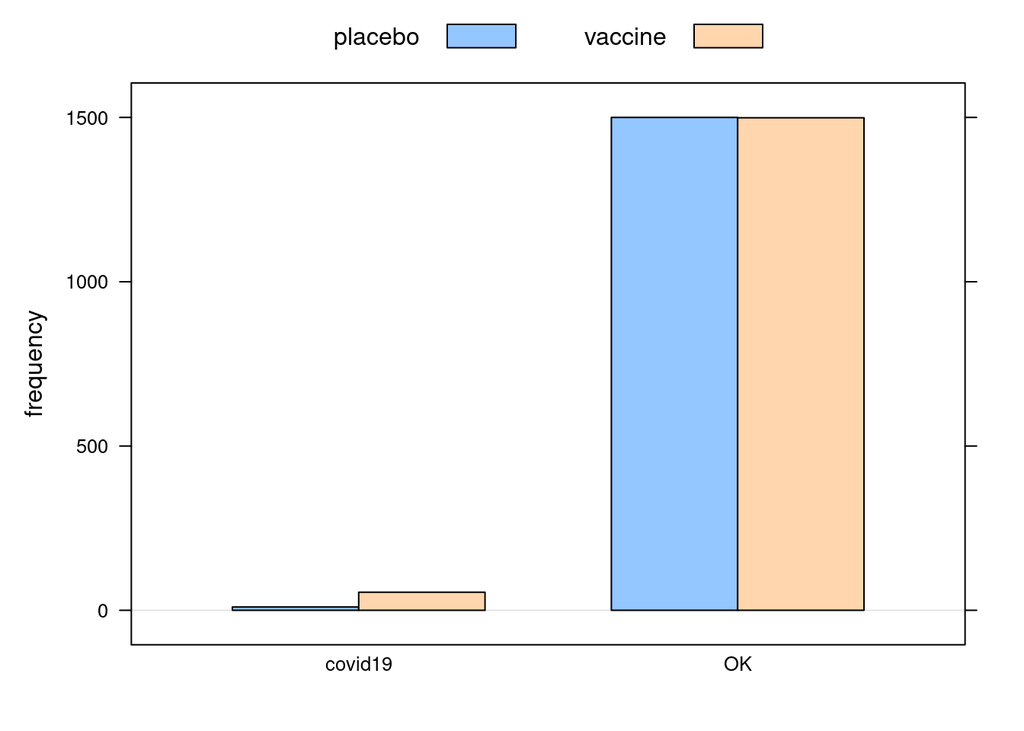

```r
barchartGC(~infected+treatment,data=LGBTQData)
```

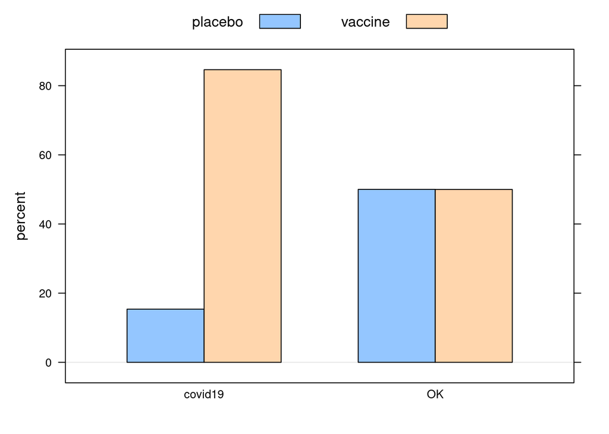

```r
barchartGC(~infected+treatment,data=LGBTQData, type="percent")
```

The graph shows among those who had covid , the LGBTQ who did got vaccine there was a difference between 80% with covid and 20% with placebo. Meanwhile Among the people who were OK that toke the vaccine, there was no significant difference.

##Numerical Descriptive Results

```r
table3 <- xtabs(~infected + treatment, data=LGBTQData)
rowPerc(table3)
```

```
##          treatment
## infected  placebo vaccine  Total
##   covid19   15.38   84.62 100.00
##   OK        50.02   49.98 100.00
```

```r
colPerc(table3)
```

```
##          treatment
## infected  placebo vaccine
##   covid19    0.66    3.54
##   OK        99.34   96.46
##   Total    100.00  100.00
```

##Inferential Results

```r
chisq.test(table3)
```

```
##
##  Pearson's Chi-squared test with Yates' continuity correction
##
## data:  table3
## X-squared = 29.159, df = 1, p-value = 6.668e-08
```

```r
chisqtestGC(table3)
```

```
## Pearson's Chi-squared test with Yates' continuity correction
##
## Observed Counts:
##          treatment
## infected  placebo vaccine
##   covid19      10      55
##   OK         1500    1499
##
## Counts Expected by Null:
##          treatment
## infected  placebo vaccine
##   covid19   32.03   32.97
##   OK      1477.97 1521.03
##
## Contributions to the chi-square statistic:
##          treatment
## infected  placebo vaccine
##   covid19   15.16   14.73
##   OK         0.33    0.32
##
##
## Chi-Square Statistic = 29.1588
## Degrees of Freedom of the table = 1
## P-Value = 0
```

```r
fisher.test(table3)
```

```
##
##  Fisher's Exact Test for Count Data
##
## data:  table3
## p-value = 1.029e-08
## alternative hypothesis: true odds ratio is not equal to 1
## 95 percent confidence interval:
##  0.08229236 0.36180711
## sample estimates:
## odds ratio
##   0.181787
```

The Chi-squared value is 0.00000006668 is too small, so vaccine is not effective in preventing spread of vaccine among LGBTQ.